# SAVI case study — STING signature on monocytic reference

### Compartment density vs matched healthy null

Same layout as the **CTRL** density grid (`plot-composition-ctrl-baseline-density`): one panel per **donor × paper compartment**. Grey density = healthy **`predict_res`** draws for that donor’s **`sex`** and **`age_decade`**; vertical line = observed proportion with tail colours and **`p_above_healthy`** / **`p_below_healthy`** labels. Below: **SAVI** and **SAVI_treated** donors only.

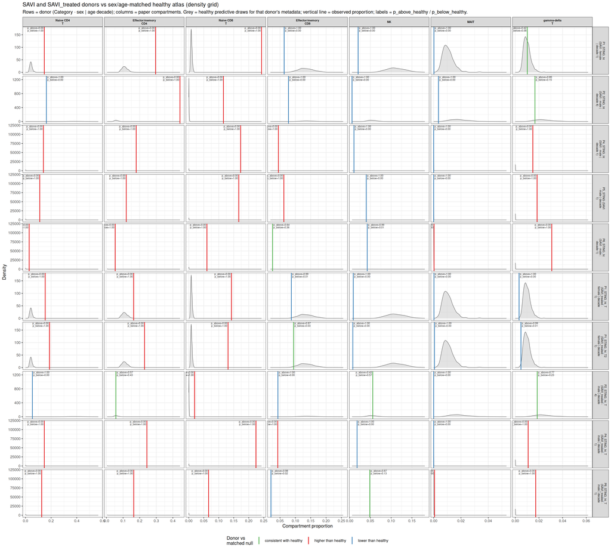

```r
compartment_levels <- paper_compartment_l3 |>
  dplyr::distinct(.data$paper_compartment) |>
  dplyr::pull(.data$paper_compartment)

atlas_null_cols <- c(
  "consistent with healthy" = "#4DAF4A",
  "higher than healthy" = "#E41A1C",
  "lower than healthy" = "#377EB8"
)

if (!exists("baseline_compartment_draws")) {
  baseline_compartment_draws <- predict_res |>
    dplyr::inner_join(
      paper_compartment_l3 |>
        dplyr::distinct(.data$paper_compartment, .data$cell_type),
      by = "cell_type"
    ) |>
    dplyr::group_by(
      .data$paper_compartment,
      .data$age_decade,
      .data$sex,
      .data$.draw
    ) |>
    dplyr::summarise(
      compartment_proportion = sum(.data$proportion),
      .groups = "drop"
    )
}

savi_cohort_atlas <- composition_matched_reference |>
  dplyr::filter(.data$Category %in% c("SAVI", "SAVI_treated")) |>
  dplyr::mutate(
    baseline_agreement = dplyr::case_when(
      .data$direction_vs_healthy == "consistent_with_healthy" ~ "consistent with healthy",
      .data$direction_vs_healthy == "higher_than_healthy" ~ "higher than healthy",
      .data$direction_vs_healthy == "lower_than_healthy" ~ "lower than healthy"
    ),
    baseline_agreement = factor(
      .data$baseline_agreement,
      levels = names(atlas_null_cols)
    ),
    sample_panel = paste0(
      .data$sample_id_observed,
      " (",
      .data$Category,
      " · ",
      .data$sex,
      " | decade ",
      .data$age_decade,
      ")"
    )
  )

savi_panel_order <- savi_cohort_atlas |>
  dplyr::distinct(.data$sample_panel, .data$Category, .data$sample_id_observed) |>
  dplyr::mutate(
    Category = factor(.data$Category, levels = c("SAVI", "SAVI_treated"))
  ) |>
  dplyr::arrange(.data$Category, .data$sample_id_observed)

savi_panel_meta <- savi_cohort_atlas |>
  dplyr::distinct(
    .data$sample_id_observed,
    .data$Category,
    .data$sex,
    .data$age_decade,
    .data$paper_compartment,
    .data$sample_panel
  )

savi_density_draws <- savi_panel_meta |>
  dplyr::inner_join(
    baseline_compartment_draws,
    by = c("sex", "age_decade", "paper_compartment")
  ) |>
  dplyr::mutate(
    sample_panel = factor(
      .data$sample_panel,
      levels = savi_panel_order$sample_panel
    ),
    paper_compartment = factor(.data$paper_compartment, levels = compartment_levels)
  ) |>
  dplyr::filter(
    is.finite(.data$compartment_proportion),
    .data$compartment_proportion >= 0
  )

savi_density_vlines <- savi_cohort_atlas |>
  dplyr::mutate(
    sample_panel = factor(
      .data$sample_panel,
      levels = savi_panel_order$sample_panel
    ),
    paper_compartment = factor(.data$paper_compartment, levels = compartment_levels),
    p_label = sprintf(
      "p_above=%.2f\np_below=%.2f",
      .data$p_above_healthy,
      .data$p_below_healthy
    )
  ) |>
  dplyr::filter(is.finite(.data$proportion_observed)) |>
  dplyr::left_join(
    savi_density_draws |>
      dplyr::group_by(.data$sample_panel, .data$paper_compartment) |>
      dplyr::summarise(
        x_mid = stats::median(.data$compartment_proportion, na.rm = TRUE),
        .groups = "drop"
      ),
    by = c("sample_panel", "paper_compartment")
  ) |>
  dplyr::mutate(
    text_hjust = dplyr::if_else(
      .data$proportion_observed > .data$x_mid,
      1.05,
      -0.05
    )
  )

ggplot2::ggplot(
  savi_density_draws,
  ggplot2::aes(x = compartment_proportion)
) +
  ggplot2::geom_density(
    fill = "grey80",
    color = "grey35",
    alpha = 0.55,
    linewidth = 0.35,
    na.rm = TRUE
  ) +
  ggplot2::geom_vline(
    data = savi_density_vlines,
    ggplot2::aes(
      xintercept = proportion_observed,
      color = baseline_agreement
    ),
    inherit.aes = FALSE,
    linewidth = 0.75
  ) +
  ggplot2::geom_text(
    data = savi_density_vlines,
    ggplot2::aes(
      x = proportion_observed,
      y = Inf,
      label = p_label,
      hjust = text_hjust
    ),
    inherit.aes = FALSE,
    vjust = 1.05,
    size = 2.1,
    lineheight = 0.85,
    color = "grey15"
  ) +
  ggplot2::facet_grid(
    sample_panel ~ paper_compartment,
    scales = "free",
    labeller = ggplot2::labeller(
      .cols = ggplot2::label_wrap_gen(10),
      .rows = ggplot2::label_wrap_gen(16)
    )
  ) +
  ggplot2::scale_color_manual(
    values = atlas_null_cols,
    name = "Donor vs\nmatched null"
  ) +
  ggplot2::scale_x_continuous(expand = ggplot2::expansion(mult = c(0.04, 0.06))) +
  ggplot2::labs(
    title = "SAVI and SAVI_treated donors vs sex/age-matched healthy atlas (density grid)",
    subtitle = paste(
      "Rows = donor (Category · sex | age decade); columns = paper compartments.",
      "Grey = healthy predictive draws for that donor's metadata;",
      "vertical line = observed proportion;",
      "labels = p_above_healthy / p_below_healthy."
    ),
    x = "Compartment proportion",
    y = "Density"
  ) +
  ggplot2::theme_bw() +
  ggplot2::theme(
    legend.position = "bottom",
    strip.text.x = ggplot2::element_text(size = 7, face = "bold"),
    strip.text.y = ggplot2::element_text(size = 7),
    panel.spacing = grid::unit(0.25, "lines")
  )
```

**How to read vs the paper**

1. **Observed cohort trends** (boxplot / bar chart): within-study CTRL vs SAVI vs SAVI_treated using observed proportions only (paper Figure 1E style). **`composition_paper_summary`**: `delta_savi_minus_ctrl` and `matches_paper_savi` flag agreement with published SAVI vs control direction.
2. **Healthy baseline by age** (line chart): how female vs male compartment proportions change across age decades 1–4 in **`predict_res`** (context for sex/age matching).
3. **CTRL vs atlas** (`plot-composition-ctrl-baseline-heatmap`, `plot-composition-ctrl-baseline-density`): sample × compartment heatmap plus per-donor density grid — grey curve = sex/age-matched healthy draws; line = observed CTRL proportion.
4. **Healthy atlas comparison** (heatmap, count/agreement bars): per donor × compartment tail test vs sex/age-matched **`predict_res`** draws (`composition_matched_reference`, `composition_savi_vs_healthy`).
5. **Compartment density plot** (`plot-composition-compartment-density`): same donor × compartment grid as CTRL — matched healthy density, tail-coloured line, **p_above** / **p_below** labels (**SAVI** and **SAVI_treated**).
6. **Fine-grained L3 table** (`composition_vs_healthy`): per donor × L3, `direction` and `empirical_confidence` with the same tail convention as gene-level deviation tests.